# Correlations_final_anon

Sebastian Wøhlk

22/1/2021

Load metabolite data

```r
metabolite_data <- read_excel("~/R/Rdata/GC_targeted_KEGGID.xlsx")
```

Load OTU bacteria data

```r
load("phyloseq_anon.Rdata")
```

Turn into relative abundance and filter data

```r
Xra <- transform_sample_counts(phyloseq_object_all,function(x) x / sum(x) )
xsub <- filter_taxa(Xra, function(x) sum(x > 0)>100, TRUE)
```

Define an OTU table as a matrix named Xotu

```r
Xotu <- otu_table(xsub) %>% t %>% as.matrix()
OTU_descrp <- data.frame(ra = apply(Xotu,2,sum), otu = colnames(Xotu))
```

Join tables to get SampleID

```r
metabo <- metabolite_data %>% left_join(metaD[,c("ID_chief","SampleID")], by = c('#SampleID' = 'ID_chief'))
```

Merge “Xotu” and the column names from “metabo”

```r
XX <- merge(Xotu, metabo[,colnames(metabo)], by.x = 'row.names',by.y = 'SampleID') %>%
  remove_rownames %>%
  column_to_rownames(var="Row.names")
```

Define “n” as the sum of complete cases in “XX”

```r
n <- sum(complete.cases(XX))
```

Define “icvar” as a logical expression

```r
icvar <- !(colnames(XX) %in% c('#SampleID.y','#SampleID'))
```

```r
cr <- cor(XX[complete.cases(XX),icvar], method = 'spearman',use = 'complete.obs')
```

Logic argument for whether colnames(cr) refer to a zOTU

```r
is_mb <- grepl('zOTU_',colnames(cr))
```

Fitting the correlation call in a data frame where “is_mb” defines whether a certain observation should be a row or column Rownames are defined as metabolite otu, metabolite and their cr are kept as cr2

```r
cr2 <- cr[!is_mb,is_mb]%>%
  as.data.frame()
cr2$metabolite <- rownames(cr2)
cr2 <- cr2 %>%
  gather(otu, cr,-metabolite)
```

#### Load the bioinformatics inferred results

```r
load('Inferred_zOTU_to_compound_relation.RData')
genome_contribution3 <- genome_contribution2 %>%
  mutate(metabolite = compound %>% substr(5,11)) %>%
  group_by(metabolite, sample_id) %>%
  dplyr::summarise(nlinks = n())
```

Define comparison

```r
comparison <- cr2 %>%
  left_join(genome_contribution3, by = c('metabolite','otu' = 'sample_id')) %>%
  left_join(OTU_descrp, by = 'otu') %>%
  ungroup %>%
  filter(!str_detect(metabolite,'_total')) %>%
  mutate(nlinks = ifelse(is.na(nlinks),0,nlinks))
```

Below I am trying to compare the number of database links to the observed correlation call

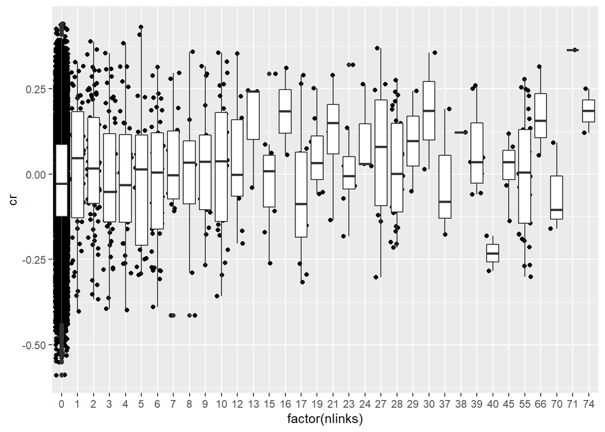

```r
comparison %>%
  ggplot(data = ., aes(factor(nlinks),cr)) +
  geom_jitter() +
  geom_boxplot()
```

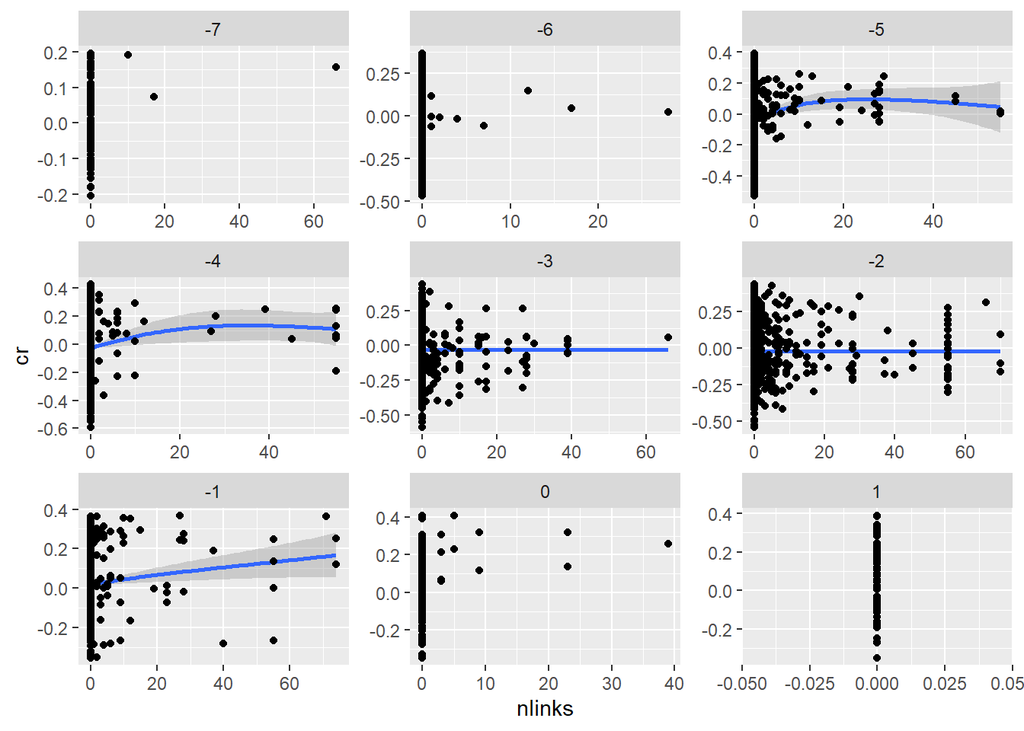

```r
comparison %>%
  mutate(fac = ra %>% log %>% round) %>%
  ggplot(data = ., aes(nlinks,cr)) +
  stat_smooth() +
  geom_point() +
  facet_wrap(~fac, scales = 'free')
```

```r
comparison <- comparison %>%
  mutate(fac = ra %>% log %>% round)
```

As links promote both positive as well as negative correlations, we can simply look at the absolute value of those.

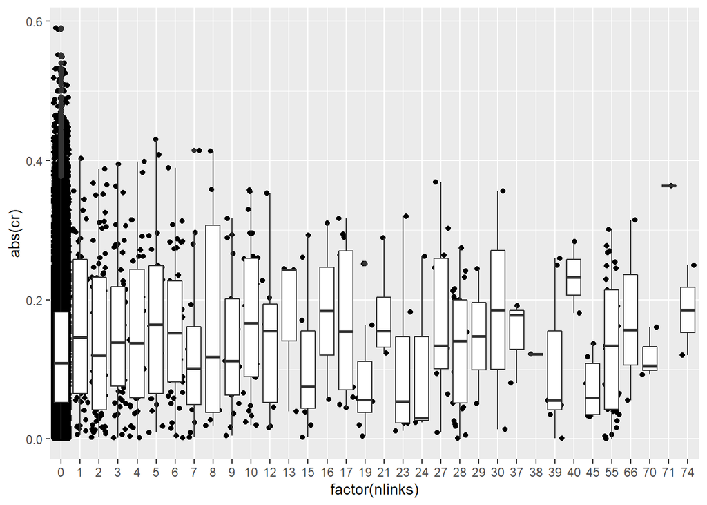

```r
comparison %>%
  ggplot(data = ., aes(factor(nlinks),abs(cr))) +
  geom_jitter() +
  geom_boxplot()
```

Or split according to whether it’s a negative or positive correlation.

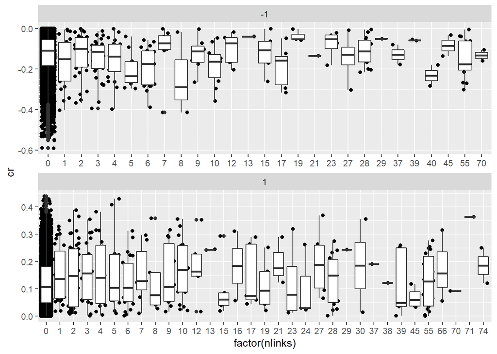

```r
comparison %>%
  mutate(signr = sign(cr)) %>%
  ggplot(data = ., aes(factor(nlinks),cr)) +
  geom_jitter() +
  geom_boxplot() +
  facet_wrap(~signr, ncol = 1, scales = 'free')
```

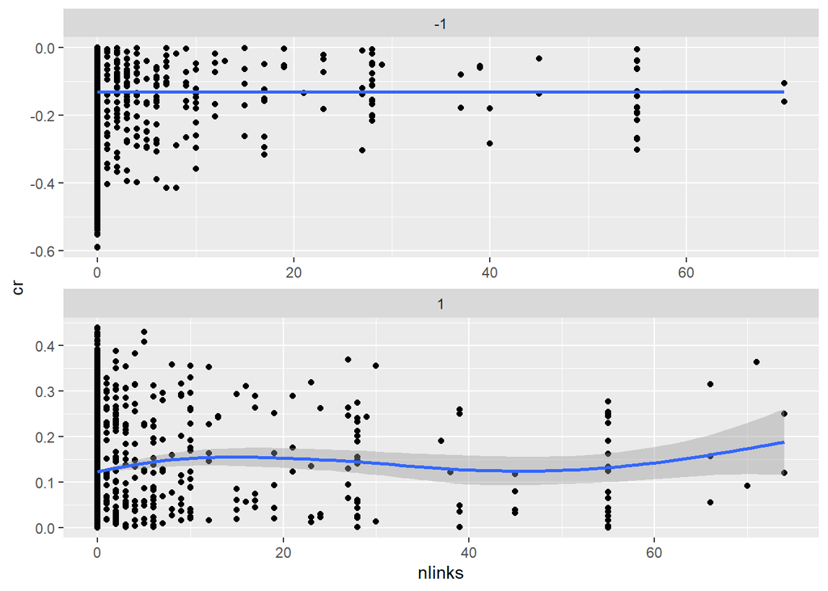

```r
comparison %>%
  mutate(signr = sign(cr)) %>%
  ggplot(data = ., aes(nlinks,cr)) +
  geom_point() +
  stat_smooth() +
  facet_wrap(~signr, ncol = 1, scales = 'free')
```